# Data Challenge 2

# Introduction

In this data challenge we were give results from an online sales price A/B test. The normal price for the product it $39 and a random sample of 33% of users were exposed to a new higher price of $59. We are given background information on users and information of their exposures to the product, including whether they made a purchase or not.

Let’s start out by taking a look at the data

```r
set.seed(101)
setwd('/Users/jalealsanjak/Documents/Research/Insight/interview_prep/data_challenge/Insight_data_challenge_2')
library(tidyverse)
library(lme4)
library(knitr)
conversion_data <- read_csv("Pricing_Test/test_results.csv")
user_data <- read_csv("Pricing_Test/user_table.csv")
all_data <- inner_join(conversion_data,user_data,by="user_id")
kable(head(all_data))
```

| user_id | timestamp | source | device | operative_system | test | price | converted | city | country | lat | long |
| --- | --- | --- | --- | --- | --- | --- | --- | --- | --- | --- | --- |
| 604839 | 2015-05-08 03:38:34 | ads_facebook | mobile | iOS | 0 | 39 | 0 | Buffalo | USA | 42.89 | -78.86 |
| 624057 | 2015-05-10 21:08:46 | seo-google | mobile | android | 0 | 39 | 0 | Lakeville | USA | 44.68 | -93.24 |
| 317970 | 2015-04-04 15:01:23 | ads-bing | mobile | android | 0 | 39 | 0 | Parma | USA | 41.38 | -81.73 |
| 685636 | 2015-05-07 07:26:01 | direct_traffic | mobile | iOS | 1 | 59 | 0 | Fayetteville | USA | 35.07 | -78.90 |
| 820854 | 2015-05-24 11:04:40 | ads_facebook | web | mac | 0 | 39 | 0 | Fishers | USA | 39.95 | -86.02 |
| 169971 | 2015-04-13 12:07:08 | ads-google | mobile | iOS | 0 | 39 | 0 | New York | USA | 40.67 | -73.94 |

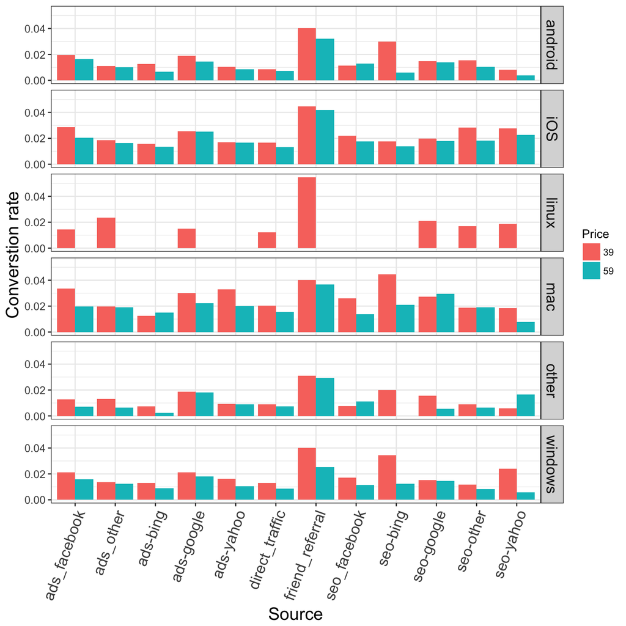

```r
conversion_rates <- all_data %>% group_by(price,source,operative_system) %>%
  summarise(conversion_rate = mean(converted),total = n(),converted=sum(converted))
p <- ggplot(conversion_rates, aes(x=source,y=conversion_rate,fill=as.factor(price))) + geom_bar(position='dodge',stat="identity") +
  theme_bw() + facet_grid(operative_system ~ .) + xlab("Source") + ylab("Converstion rate")+ guides(fill=guide_legend("Price"))
p <- p + theme(axis.text.x = element_text(angle = 70,hjust=1,size=14),
          axis.text.y = element_text(size=10),
          axis.title =element_text(size=16),
          strip.text.x= element_text(size=14),
          strip.text.y= element_text(size=14))
```

# Modeling approach

It appears that there is a decent bit of variation amongst the different sources of referral to the site and the operating system. It appears that friend referrals have the highest converstion rate and that linux users are extremely prive sensitive (althought the sample size is low for linux).

Given the structure in these data, my first thought was to use a linear mixed effects model. More specifically, because our response data is binomial (0/1 for converted and not converted) we use a generalized linear mixed effects model (glmm) with a binomial error model and logit link, i.e. a logistic mixed effects model.

(G)LMMs are a broad family of models that can account for multiple levels of structure in the data. There are fixed effects and random effects.

```r
####
#conversion_model_slope <- glmer(converted ~ price + (1 + price | source) + (1 + price | operative_system) , data=all_data, family=binomial(link="logit"))
conversion_model_slope <- readRDS("conversion_slope_model.rds")
summary(conversion_model_slope)
```

```
## Generalized linear mixed model fit by maximum likelihood (Laplace
##   Approximation) [glmerMod]
##  Family: binomial  ( logit )
## Formula:
## converted ~ price + (1 + price | source) + (1 + price | operative_system)
##    Data: all_data
##
##      AIC      BIC   logLik deviance df.resid
##  49398.5  49482.8 -24691.3  49382.5   275608
##
## Scaled residuals:
##     Min      1Q  Median      3Q     Max
## -0.2358 -0.1487 -0.1287 -0.1127 12.1453
##
## Random effects:
##  Groups           Name        Variance  Std.Dev. Corr
##  source           (Intercept) 9.331e-02 0.305469
##                   price       2.882e-06 0.001698 -0.01
##  operative_system (Intercept) 2.717e+00 1.648299
##                   price       1.985e-03 0.044551 -0.99
## Number of obs: 275616, groups:  source, 12; operative_system, 6
##
## Fixed effects:
##             Estimate Std. Error z value Pr(>|z|)
## (Intercept) -2.75742    0.37768  -7.301 2.86e-13 ***
## price       -0.03251    0.01050  -3.097  0.00196 **
## ---
## Signif. codes:  0 '***' 0.001 '**' 0.01 '*' 0.05 '.' 0.1 ' ' 1
##
## Correlation of Fixed Effects:
##       (Intr)
## price -0.939
## convergence code: 0
## Model failed to converge with max|grad| = 0.00947359 (tol = 0.001, component 1)
## Model is nearly unidentifiable: very large eigenvalue
##  - Rescale variables?
```

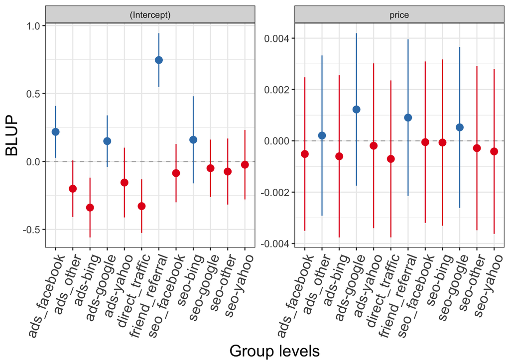

```r
library(lme4)
library(sjPlot)

p <- sjp.lmer(conversion_model_slope,free.scale=TRUE,
               prnt.plot = FALSE,show.values=FALSE)$plot.list

plot(p[[1]] + theme_bw() + theme(axis.text.x = element_text(angle = 70,hjust=1,size=14),
                  axis.text.y = element_text(size=10),
                  axis.title =element_text(size=16) ))
```

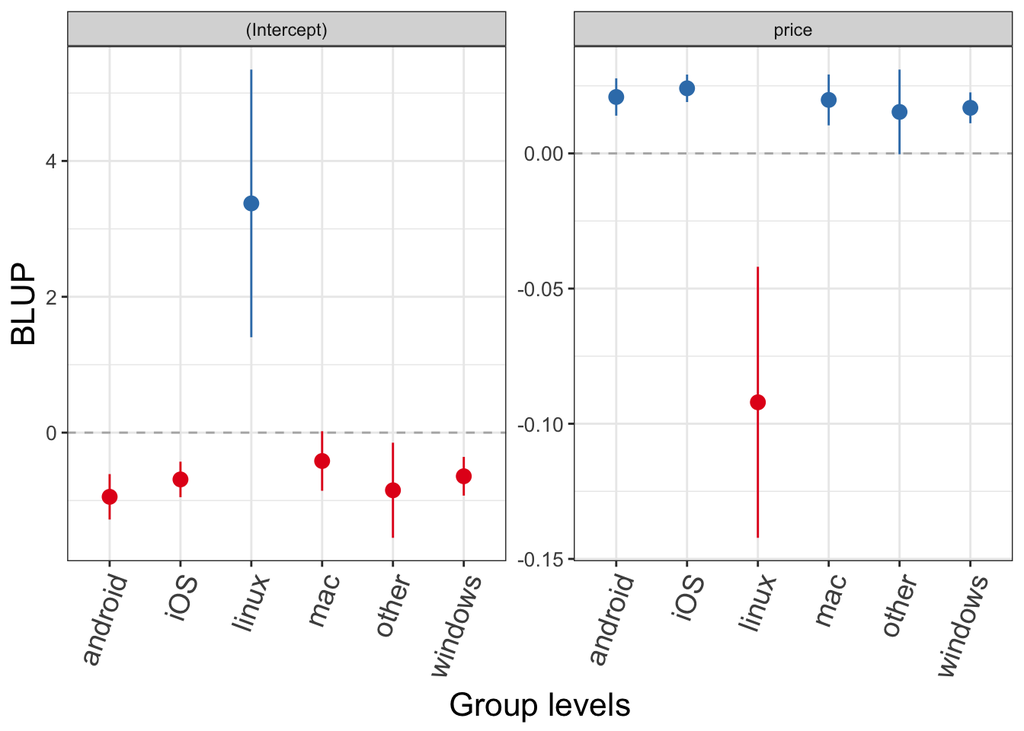

```r
plot(p[[2]] + theme_bw() + theme(axis.text.x = element_text(angle = 70,hjust=1,size=14),
                  axis.text.y = element_text(size=10),
                  axis.title =element_text(size=16) ))
```

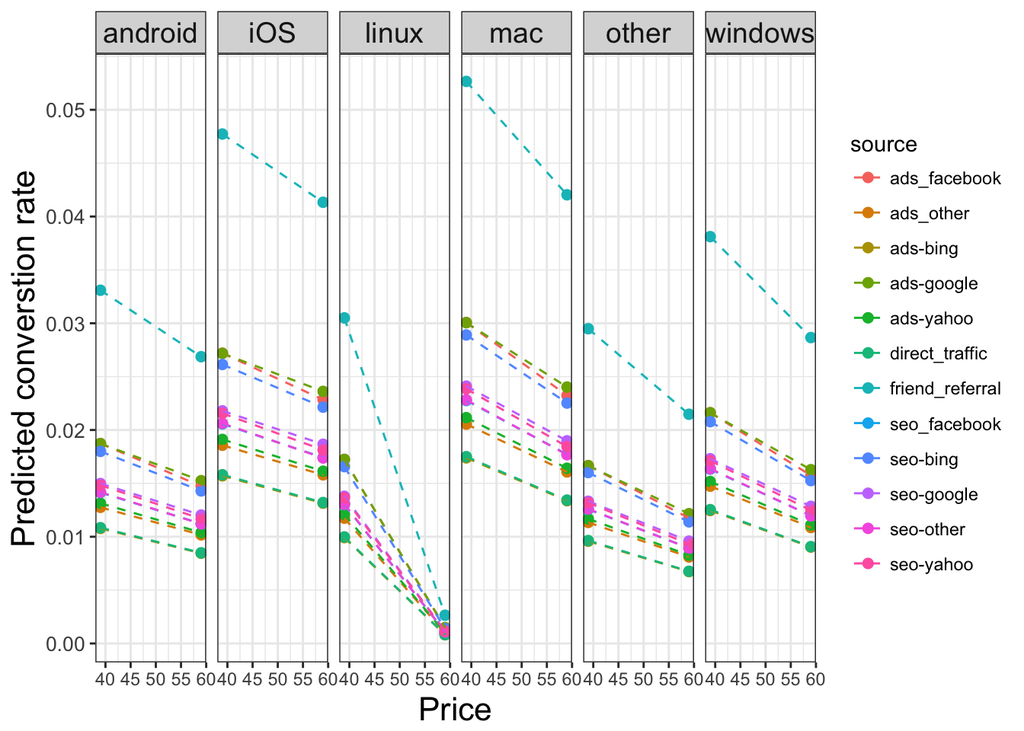

```r
model_mat <- all_data %>% group_by(price,source,operative_system) %>%
  summarise(N=n()) %>% select(price,source,operative_system)

pred_or <- predict(conversion_model_slope,newdata=model_mat,type="response")
model_mat <- ungroup(model_mat) %>% mutate(predicted = pred_or)

p <- ggplot(model_mat,aes(price,predicted,color = source)) +
  geom_point(size=2) + geom_line(linetype="dashed") + facet_grid(.~operative_system) + xlab("Price") + ylab("Predicted converstion rate")

p + theme_bw() + theme(axis.text.y = element_text(size=10),
                      axis.title =element_text(size=16),
                      strip.text.x= element_text(size=14),
                      strip.text.y= element_text(size=14))
```

# Discussion

There are a few things that are apparrent from the mixed effect model.

- In general price has a negative effect on conversion rate, as expected
- Friend referral is more effective than any other other source of advertising.
- Facebook is also slightly more effective
- Bing and direct traffic seem to perform poorly
- Linux users appear to be extremely price sensitive

## Questions

### Should the company sell at the higher price?

Based on my analyses, yes the company should sell at the higher price. If we assume that raising the price does not effect the composition or the total of their usership, then we can simply look at the average conversion rate between the two price groups. Taking the product of the average rate and the price gives us the expected revenue per user.

```r
conversion_mean <- all_data %>% group_by(price) %>% summarise(total= n(),conversion_rate= mean(converted)) %>% mutate(revenue = price*conversion_rate)
kable(conversion_mean)
```

| price | total | conversion_rate | revenue |
| --- | --- | --- | --- |
| 39 | 176376 | 0.0197533 | 0.7703769 |
| 59 | 99240 | 0.0154676 | 0.9125857 |

### How long did this test need to be?

This is a question about power. We want to know what our sample size needs to be in order to detect a certain effect size of interest. To do this, we need to determine what a relevant effect size is. In this case, perhaps it is the break even point. At the break even point:

$$conversion_1 * price_1 = conversion_2 * price_2$$

$$conversion_1 * \frac{price_1}{price_2} = conversion_2$$

```r
break_even_rate = conversion_mean$conversion_rate[1]*39/59
break_even_rate
```

```
## [1] 0.01305724
```

In general, doing power analysis on GLMM’s is pretty challenging and typically requires simulation. I did not have time to implement this. Therefore I will use a more simple approach where I am testing the power of a two-sample proportion test. This tests the null hypothesis that the proportions of conversions (conversion rate) is the same in the two samples. This would represent our ability to see a difference in total conversion rate between the two price groups either a) overall or b) within a specific group. I also checked the power assuming we did a chi-squared test on the 2*2 price by converted converted contingency table

### Overall two sample power at $\alpha=0.05$

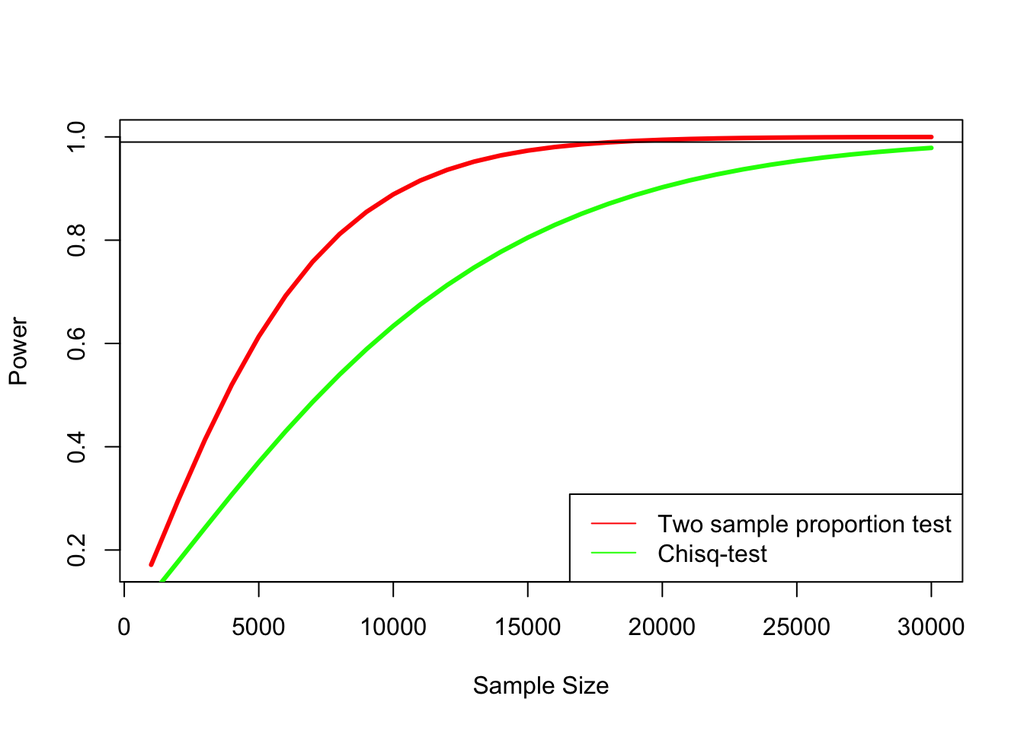

```r
library(pwr)
N = seq(1000,30000,1000)
N2_ratio = conversion_mean$total[2]/conversion_mean$total[1]
power_2p = sapply(N,function(x) pwr.2p2n.test(h = ES.h(p1 =conversion_mean$conversion_rate[1],
                                                    p2 = break_even_rate),
                                          n1=x,n2=N2_ratio*x, sig.level = 0.05)$power)

all_data_fake <- all_data %>% group_by(price) %>% mutate(conversion=ifelse(price == 39, conversion_mean$conversion_rate[1],break_even_rate))
all_data_fake <- ungroup(all_data_fake) %>% mutate(simulated = rbinom(nrow(all_data_fake),1,prob =all_data_fake$conversion))

chisq_test_real <- chisq.test(table(all_data$price,all_data$converted))
chisq_test_fake <- chisq.test(table(all_data_fake$price,all_data_fake$simulated))
eff_size <- sqrt(chisq_test_fake$statistic/sum(chisq_test_fake$observed)) #chi squared effect size

power_chisq = sapply(N,function(x) pwr.chisq.test(w=eff_size,N=x,df=1,sig.level=0.05)$power)



plot(N,power_2p,type='l',col='red',ylab = "Power",xlab="Sample Size",lwd=3)
lines(N,power_chisq,col='green',lwd=3)
abline(h=0.99)
legend("bottomright",lty=c(1,1),col=c('red','green'),legend = c("Two sample proportion test","Chisq-test"))
```